# K-means

Santiago Casanova, Mateo Guajardo y Raúl Pineda

2023-12-14

### ¿Qué es K-means?

Primero, comenzaremos definiendo que es un $\textit{cluster}$. Aunque no hay una definición exacta, nosotros vamos a dar una idea un poco general de lo que este termino engloba. Un $\textit{cluster}$, en el contexto de análisis de datos y estadística, es un conjunto de elementos que comparten características similares. En otras palabras, es un grupo de datos que se parecen entre sí más de lo que se parecen a datos de otros grupos. La definición completa de un cluster involucra varios aspectos clave:

1. Similitud: Los elementos dentro de un cluster son similares entre sí. Esta similitud suele medirse en términos de distancia (como la distancia euclidiana) o correlación, dependiendo del tipo de datos y del método de clustering utilizado.
2. Homogeneidad Interna: Dentro de un cluster, los elementos deben ser lo más homogéneos posible. Esto significa que comparten un grado significativo de características comunes, lo que los hace agruparse.
3. Heterogeneidad Externa: Los elementos de diferentes clusters deben ser claramente distintos y deben tener diferencias significativas entre los grupos.
4. Formación Espontánea: En muchos métodos de clustering, como k-means, los clusters se forman de manera orgánica a partir de los datos, sin intervención externa en términos de definir las características del cluster.
5. Propósito de Análisis: Un cluster se forma generalmente con el propósito de realizar algún tipo de análisis de datos. Esto puede ser para entender mejor la estructura subyacente de los datos, para la toma de decisiones, para la segmentación de mercado, entre otros.
6. Variedad de Aplicaciones: El clustering se utiliza en una amplia gama de campos, desde la biología (agrupación de genes o especies) hasta el marketing (segmentación de clientes) y la geografía (agrupación de ubicaciones geográficas con características similares).

En resumen, un cluster es un grupo de elementos que son significativamente similares entre sí y diferentes de los elementos en otros grupos, formados con el objetivo de analizar o entender los datos de una manera más estructurada y significativa.

K-means es un algoritmo de aprendizaje no supervisado que se utiliza para agrupar datos en $k$ número de clusters. Es particularmente útil cuando tienes un conjunto de datos y quieres identificar patrones o grupos subyacentes en él. La “$k$” en k-means representa el número de clusters que quieres formar.

El algoritmo funciona asignando puntos a clusters de tal manera que la suma de las distancias cuadradas entre los puntos de datos y el centroide (punto central) de su cluster sea mínima. En otras palabras, el objetivo es minimizar la varianza dentro de cada cluster. Matemáticamente lo podemos escribir como:

$$\min_{S} \sum_{i=1}^{k} \sum_{x \in
S_i} \| x - \mu_i \|^2$$

Donde:

1. $k$ es el número de clusters.
2. $S = \{S_1, S_2, ... , S_k\}$ es el conjunto de todos los clusters.
3. $x$ representa los puntos de datos en el espacio.
4. $\mu_i$ es el centroide del cluster $S_i$.
5. $\| x - \mu_i \|^2$ es la distancia cuadrada euclidiana entre un punto $x$ y el centroide $\mu_i$.

### Algoritmo

Los pasos del algoritmo de K-means son los siguientes:

1. Inicialización: Se seleccionan al azar $k$ puntos como centroides iniciales.
2. Asignación: Cada punto del conjunto de datos se asigna al centroide más cercano.
3. Actualización: Se recalcula el centroide de cada cluster como el promedio de todos los puntos asignados a ese cluster.
4. teración: Los pasos 2. y 3rau. se repiten hasta que los centroides no cambien significativamente entre iteraciones sucesivas o se alcance un límite de iteraciones.

### Supuestos

Los supuestos de K-means son:

1. La varianza de la distribución de cada variables es esférica
2. Todas las variables tienen la misma varianza
3. Cada cluster tiene aproximadamente el mismo número de observaciones

### Ejemplo de K-means aplicado

Para nuestro ejemplo, utilizaremos el dataset iris en cada paso. Este dataset describe las características (largo y ancho de pétalos y sépalos) de una muestra de 3 tipos diferentes de flores. En realidad ya conocemos que representa cada dato, sin embargo para el ejercicio supondremos que son datos no etiquetados. Veamos la distribución de los datos para nuestras especies.

```r
require(psych)
```

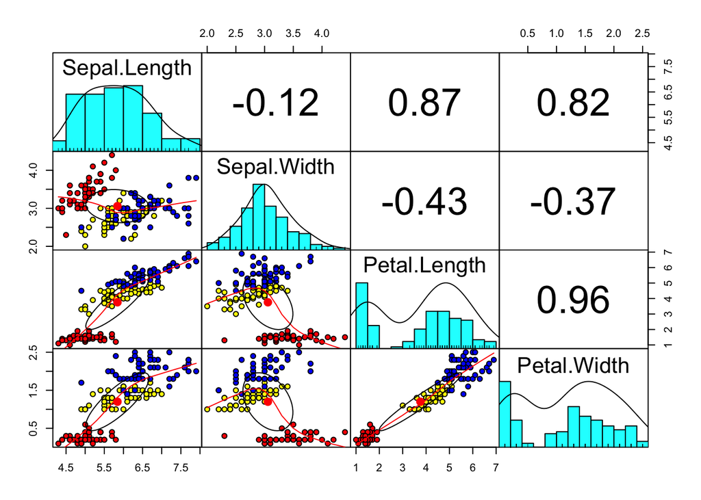

```r
pairs.panels(iris[,-5],
             gap = 0,
             bg = c("red", "yellow", "blue")[iris$Species],
             pch=21)
```